# Menatl Helath Cases in Karnataka Case Study

# Importing Data Set

| SL No | DISTRICT | SEVERE_MENTAL_DISORDER_(SMD) | COMMON_MENTAL _DISORDER(CMD) | ALCOHOL_&_SUBSTANCE_ABUSE | CASES_REFERRED_TO_HIGHER_CENTRES | SUICIDE_ATTEMPT_CASES | Others | Total |
| --- | --- | --- | --- | --- | --- | --- | --- | --- |
| 1 | BAGALKOTE | 2833 | 2937 | 238 | 41 | 31 | 8393 | 14473 |
| 2 | BANGALORE RURAL | 3053 | 8975 | 1437 | 602 | 188 | 9499 | 23754 |
| 3 | BANGALORE URBAN | 7601 | 25663 | 4747 | 687 | 609 | 14648 | 53955 |
| 4 | BELGAUM | 10901 | 15740 | 3663 | 782 | 784 | 28139 | 60009 |
| 5 | BELLARY | 11153 | 10998 | 5585 | 26 | 3517 | 16576 | 47855 |
| 6 | BIDAR | 13400 | 31487 | 17556 | 2533 | 3 | 25839 | 90818 |

## 1. Top 10 District having a Suicide cases due to Mental Health Issues .

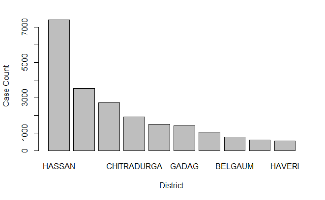

## 2. Top 5 Districts having that possess high Mental Health Issues Cases due to Alcohol Consumption

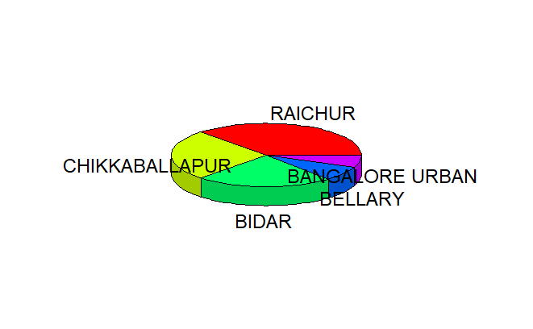

## 3. Construction of Boxplot to understand distribution of Common and Severe Mental Health Disorder.

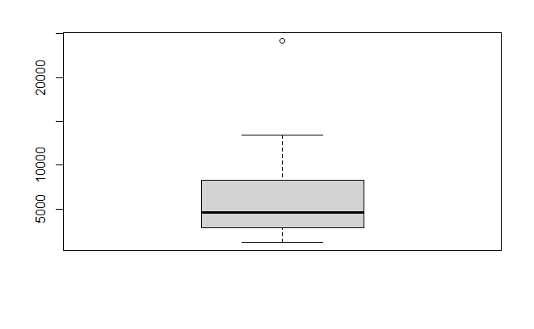

```r
SMD <- DS1$`SEVERE_MENTAL_DISORDER_(SMD)`
CMD <- DS1 $`COMMON_MENTAL _DISORDER(CMD)`

boxplot(SMD)
```

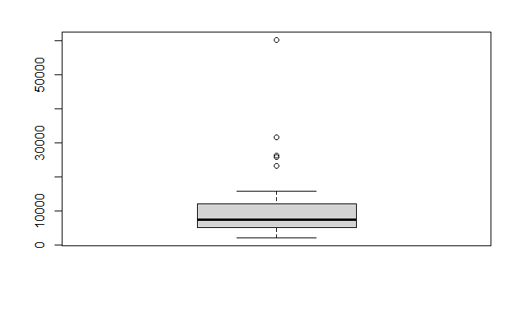

```r
boxplot(CMD)
```

## 4. Performing linear regression factors affecting Severe Mental Disorder.

```r
model<- lm(DS1$`SEVERE_MENTAL_DISORDER_(SMD)`~DS1$`ALCOHOL_&_SUBSTANCE_ABUSE`)
summary(model)
```

```
Call:
lm(formula = DS1$`SEVERE_MENTAL_DISORDER_(SMD)` ~ DS1$`ALCOHOL_&_SUBSTANCE_ABUSE`)

Residuals:
    Min      1Q  Median      3Q     Max
-6617.1 -1679.0  -418.6  2003.7  4802.1

Coefficients:
                                 Estimate Std. Error t value Pr(>|t|)
(Intercept)                     3.893e+03  5.635e+02   6.910 1.64e-07 ***
DS1$`ALCOHOL_&_SUBSTANCE_ABUSE` 6.021e-01  7.682e-02   7.838 1.55e-08 ***
---
Signif. codes:  0 ‘***’ 0.001 ‘**’ 0.01 ‘*’ 0.05 ‘.’ 0.1 ‘ ’ 1

Residual standard error: 2658 on 28 degrees of freedom
Multiple R-squared:  0.6869,    Adjusted R-squared:  0.6757
F-statistic: 61.43 on 1 and 28 DF,  p-value: 1.545e-08
```

The model Concludes that the effect of Alcohol and Substance abuse effect is statistically significant.

The R-squared value of 0.6869 indicates that 68.69% of the variance in the dependent variable can be explained by the independent variable.

## 5.Performing Two tailed test to show the mean difference between Common Mental Health Disorder and Severe Mental Health Disorder.

```r
res <- t.test(SMD,CMD)
res
```

```
    Welch Two Sample t-test

data:  SMD and CMD
t = -2.2013, df = 37.587, p-value = 0.03393
alternative hypothesis: true difference in means is not equal to 0
95 percent confidence interval:
 -9929.2950  -413.8384
sample estimates:
mean of x mean of y
 6138.867 11310.433
```

```r
summary(res)
```

```
            Length Class  Mode
statistic   1      -none- numeric
parameter   1      -none- numeric
p.value     1      -none- numeric
conf.int    2      -none- numeric
estimate    2      -none- numeric
null.value  1      -none- numeric
stderr      1      -none- numeric
alternative 1      -none- character
method      1      -none- character
data.name   1      -none- character
```

> The above test helps us to understand that there is a significant difference between Common mental Disorder and Severe Mental Health Disorder cases.

> The **p-value (0.03393)** is the probability of observing a t-statistic as extreme or more extreme than the one observed, assuming that the null hypothesis is true